# MSDS6306_LSHW13_A.Horacek

MSDS 6306_Live Session Homework 13--Angela Horacek

### 1. CREATE A LIST NAMED my_list IN PYTHON WITH THE FOLLOWING DATA POINTS:

```python
my_list = [45.4, 44.2, 36.8, 35.1, 39.0, 60.0, 47.4, 41.1, 45.8, 35.6]
```

1.a. Print the 5th element in the list.

```python
my_list[4]
```

```
39.0
```

1.b. Append 55.2 to my_list

```python
var1 = 55.2
my_list.append(var1)
print (my_list)
```

```
[45.4, 44.2, 36.8, 35.1, 39.0, 60.0, 47.4, 41.1, 45.8, 35.6, 55.2]
```

1.c. Remove the 6th element in the list.

```python
del my_list [5]
print (my_list)
```

```
[45.4, 44.2, 36.8, 35.1, 39.0, 47.4, 41.1, 45.8, 35.6, 55.2]
```

1.d Iterate over the list to print data points greater than 45.

```python
for val in my_list:
    if val > 45:
        print (val)
```

```
45.4
47.4
45.8
55.2
```

### 2. INTRODUCTION TO NUMPY

2.a. Import the numpy library using the following command import numpy.

```python
import numpy
```

2.b. Declare numpy array with the same data points as in my_list using numpy.array()

```python
array1 = numpy.array([45.4, 44.2, 36.8, 35.1, 39.0, 60.0, 47.4, 41.1, 45.8, 35.6])
print (array1)
```

```
[ 45.4  44.2  36.8  35.1  39.   60.   47.4  41.1  45.8  35.6]
```

2.c. Compute the mean and standard deviation using numpy.mean() and numpy.std() of the above array.

```python
mean1 = numpy.mean(array1)
print ("Mean is", mean1)
sd1 = numpy.std(array1)
print ("Standard deviation is", sd1)
```

```
Mean is 43.04
Standard deviation is 7.06118970146
```

2.d. Use logical referencing to get only those values that are less than 45.

```python
array1[numpy.where(array1<45)]
```

```
array([ 44.2,  36.8,  35.1,  39. ,  41.1,  35.6])
```

2.e. Compute the max and min or the array using numpy.max() and numpy.min().

```python
max1 = numpy.max(array1)
print ("Max is", max1)
min1 = numpy.min(array1)
print ("Min is", min1)
```

```
Max is 60.0
Min is 35.1
```

### 3. INTRODUCTION TO PANDAS

3.a. Import the pandas library-import pandas.

```python
import pandas
```

3.b. Read the IRIS dataset into iris using pandas.read_csv(). Data file-

```python
iris = pandas.read_csv("C:/Users/Angela/Anaconda3/Lib/site-packages/blaze/examples/data/iris.csv")
```

3.c. Using iris.head(), display the head of the dataset. Note: I had to add an "id" column into the original file to show that I could drop the id column in 3.d.

```python
iris.head()
```

|  | id | sepal_length | sepal_width | petal_length | petal_width | species |
| --- | --- | --- | --- | --- | --- | --- |
| 0 | 1 | 5.1 | 3.5 | 1.4 | 0.2 | Iris-setosa |
| 1 | 2 | 4.9 | 3.0 | 1.4 | 0.2 | Iris-setosa |
| 2 | 3 | 4.7 | 3.2 | 1.3 | 0.2 | Iris-setosa |
| 3 | 4 | 4.6 | 3.1 | 1.5 | 0.2 | Iris-setosa |
| 4 | 5 | 5.0 | 3.6 | 1.4 | 0.2 | Iris-setosa |

3.d. Use DataFrame.drop() to drop the id column.

```python
iris1=iris.drop(iris.columns[[0]], axis=1)
iris1
```

|  | sepal_length | sepal_width | petal_length | petal_width | species |
| --- | --- | --- | --- | --- | --- |
| 0 | 5.1 | 3.5 | 1.4 | 0.2 | Iris-setosa |
| 1 | 4.9 | 3.0 | 1.4 | 0.2 | Iris-setosa |
| 2 | 4.7 | 3.2 | 1.3 | 0.2 | Iris-setosa |
| 3 | 4.6 | 3.1 | 1.5 | 0.2 | Iris-setosa |
| 4 | 5.0 | 3.6 | 1.4 | 0.2 | Iris-setosa |
| 5 | 5.4 | 3.9 | 1.7 | 0.4 | Iris-setosa |
| 6 | 4.6 | 3.4 | 1.4 | 0.3 | Iris-setosa |
| 7 | 5.0 | 3.4 | 1.5 | 0.2 | Iris-setosa |
| 8 | 4.4 | 2.9 | 1.4 | 0.2 | Iris-setosa |
| 9 | 4.9 | 3.1 | 1.5 | 0.1 | Iris-setosa |
| 10 | 5.4 | 3.7 | 1.5 | 0.2 | Iris-setosa |
| 11 | 4.8 | 3.4 | 1.6 | 0.2 | Iris-setosa |
| 12 | 4.8 | 3.0 | 1.4 | 0.1 | Iris-setosa |
| 13 | 4.3 | 3.0 | 1.1 | 0.1 | Iris-setosa |
| 14 | 5.8 | 4.0 | 1.2 | 0.2 | Iris-setosa |
| 15 | 5.7 | 4.4 | 1.5 | 0.4 | Iris-setosa |
| 16 | 5.4 | 3.9 | 1.3 | 0.4 | Iris-setosa |
| 17 | 5.1 | 3.5 | 1.4 | 0.3 | Iris-setosa |
| 18 | 5.7 | 3.8 | 1.7 | 0.3 | Iris-setosa |
| 19 | 5.1 | 3.8 | 1.5 | 0.3 | Iris-setosa |
| 20 | 5.4 | 3.4 | 1.7 | 0.2 | Iris-setosa |
| 21 | 5.1 | 3.7 | 1.5 | 0.4 | Iris-setosa |
| 22 | 4.6 | 3.6 | 1.0 | 0.2 | Iris-setosa |
| 23 | 5.1 | 3.3 | 1.7 | 0.5 | Iris-setosa |
| 24 | 4.8 | 3.4 | 1.9 | 0.2 | Iris-setosa |
| 25 | 5.0 | 3.0 | 1.6 | 0.2 | Iris-setosa |
| 26 | 5.0 | 3.4 | 1.6 | 0.4 | Iris-setosa |
| 27 | 5.2 | 3.5 | 1.5 | 0.2 | Iris-setosa |
| 28 | 5.2 | 3.4 | 1.4 | 0.2 | Iris-setosa |
| 29 | 4.7 | 3.2 | 1.6 | 0.2 | Iris-setosa |
| ... | ... | ... | ... | ... | ... |
| 120 | 6.9 | 3.2 | 5.7 | 2.3 | Iris-virginica |
| 121 | 5.6 | 2.8 | 4.9 | 2.0 | Iris-virginica |
| 122 | 7.7 | 2.8 | 6.7 | 2.0 | Iris-virginica |
| 123 | 6.3 | 2.7 | 4.9 | 1.8 | Iris-virginica |
| 124 | 6.7 | 3.3 | 5.7 | 2.1 | Iris-virginica |
| 125 | 7.2 | 3.2 | 6.0 | 1.8 | Iris-virginica |
| 126 | 6.2 | 2.8 | 4.8 | 1.8 | Iris-virginica |
| 127 | 6.1 | 3.0 | 4.9 | 1.8 | Iris-virginica |
| 128 | 6.4 | 2.8 | 5.6 | 2.1 | Iris-virginica |
| 129 | 7.2 | 3.0 | 5.8 | 1.6 | Iris-virginica |
| 130 | 7.4 | 2.8 | 6.1 | 1.9 | Iris-virginica |
| 131 | 7.9 | 3.8 | 6.4 | 2.0 | Iris-virginica |
| 132 | 6.4 | 2.8 | 5.6 | 2.2 | Iris-virginica |
| 133 | 6.3 | 2.8 | 5.1 | 1.5 | Iris-virginica |
| 134 | 6.1 | 2.6 | 5.6 | 1.4 | Iris-virginica |
| 135 | 7.7 | 3.0 | 6.1 | 2.3 | Iris-virginica |
| 136 | 6.3 | 3.4 | 5.6 | 2.4 | Iris-virginica |
| 137 | 6.4 | 3.1 | 5.5 | 1.8 | Iris-virginica |
| 138 | 6.0 | 3.0 | 4.8 | 1.8 | Iris-virginica |
| 139 | 6.9 | 3.1 | 5.4 | 2.1 | Iris-virginica |
| 140 | 6.7 | 3.1 | 5.6 | 2.4 | Iris-virginica |
| 141 | 6.9 | 3.1 | 5.1 | 2.3 | Iris-virginica |
| 142 | 5.8 | 2.7 | 5.1 | 1.9 | Iris-virginica |
| 143 | 6.8 | 3.2 | 5.9 | 2.3 | Iris-virginica |
| 144 | 6.7 | 3.3 | 5.7 | 2.5 | Iris-virginica |
| 145 | 6.7 | 3.0 | 5.2 | 2.3 | Iris-virginica |
| 146 | 6.3 | 2.5 | 5.0 | 1.9 | Iris-virginica |
| 147 | 6.5 | 3.0 | 5.2 | 2.0 | Iris-virginica |
| 148 | 6.2 | 3.4 | 5.4 | 2.3 | Iris-virginica |
| 149 | 5.9 | 3.0 | 5.1 | 1.8 | Iris-virginica |

150 rows × 5 columns

3.e. Subset dataframe to create a new data frame that includes only the measurements for the setosa species.

```python
setosa_df = iris1[iris1.species == "Iris-setosa"]
setosa_df
```

|  | sepal_length | sepal_width | petal_length | petal_width | species |
| --- | --- | --- | --- | --- | --- |
| 0 | 5.1 | 3.5 | 1.4 | 0.2 | Iris-setosa |
| 1 | 4.9 | 3.0 | 1.4 | 0.2 | Iris-setosa |
| 2 | 4.7 | 3.2 | 1.3 | 0.2 | Iris-setosa |
| 3 | 4.6 | 3.1 | 1.5 | 0.2 | Iris-setosa |
| 4 | 5.0 | 3.6 | 1.4 | 0.2 | Iris-setosa |
| 5 | 5.4 | 3.9 | 1.7 | 0.4 | Iris-setosa |
| 6 | 4.6 | 3.4 | 1.4 | 0.3 | Iris-setosa |
| 7 | 5.0 | 3.4 | 1.5 | 0.2 | Iris-setosa |
| 8 | 4.4 | 2.9 | 1.4 | 0.2 | Iris-setosa |
| 9 | 4.9 | 3.1 | 1.5 | 0.1 | Iris-setosa |
| 10 | 5.4 | 3.7 | 1.5 | 0.2 | Iris-setosa |
| 11 | 4.8 | 3.4 | 1.6 | 0.2 | Iris-setosa |
| 12 | 4.8 | 3.0 | 1.4 | 0.1 | Iris-setosa |
| 13 | 4.3 | 3.0 | 1.1 | 0.1 | Iris-setosa |
| 14 | 5.8 | 4.0 | 1.2 | 0.2 | Iris-setosa |
| 15 | 5.7 | 4.4 | 1.5 | 0.4 | Iris-setosa |
| 16 | 5.4 | 3.9 | 1.3 | 0.4 | Iris-setosa |
| 17 | 5.1 | 3.5 | 1.4 | 0.3 | Iris-setosa |
| 18 | 5.7 | 3.8 | 1.7 | 0.3 | Iris-setosa |
| 19 | 5.1 | 3.8 | 1.5 | 0.3 | Iris-setosa |
| 20 | 5.4 | 3.4 | 1.7 | 0.2 | Iris-setosa |
| 21 | 5.1 | 3.7 | 1.5 | 0.4 | Iris-setosa |
| 22 | 4.6 | 3.6 | 1.0 | 0.2 | Iris-setosa |
| 23 | 5.1 | 3.3 | 1.7 | 0.5 | Iris-setosa |
| 24 | 4.8 | 3.4 | 1.9 | 0.2 | Iris-setosa |
| 25 | 5.0 | 3.0 | 1.6 | 0.2 | Iris-setosa |
| 26 | 5.0 | 3.4 | 1.6 | 0.4 | Iris-setosa |
| 27 | 5.2 | 3.5 | 1.5 | 0.2 | Iris-setosa |
| 28 | 5.2 | 3.4 | 1.4 | 0.2 | Iris-setosa |
| 29 | 4.7 | 3.2 | 1.6 | 0.2 | Iris-setosa |
| 30 | 4.8 | 3.1 | 1.6 | 0.2 | Iris-setosa |
| 31 | 5.4 | 3.4 | 1.5 | 0.4 | Iris-setosa |
| 32 | 5.2 | 4.1 | 1.5 | 0.1 | Iris-setosa |
| 33 | 5.5 | 4.2 | 1.4 | 0.2 | Iris-setosa |
| 34 | 4.9 | 3.1 | 1.5 | 0.2 | Iris-setosa |
| 35 | 5.0 | 3.2 | 1.2 | 0.2 | Iris-setosa |
| 36 | 5.5 | 3.5 | 1.3 | 0.2 | Iris-setosa |
| 37 | 4.9 | 3.6 | 1.4 | 0.1 | Iris-setosa |
| 38 | 4.4 | 3.0 | 1.3 | 0.2 | Iris-setosa |
| 39 | 5.1 | 3.4 | 1.5 | 0.2 | Iris-setosa |
| 40 | 5.0 | 3.5 | 1.3 | 0.3 | Iris-setosa |
| 41 | 4.5 | 2.3 | 1.3 | 0.3 | Iris-setosa |
| 42 | 4.4 | 3.2 | 1.3 | 0.2 | Iris-setosa |
| 43 | 5.0 | 3.5 | 1.6 | 0.6 | Iris-setosa |
| 44 | 5.1 | 3.8 | 1.9 | 0.4 | Iris-setosa |
| 45 | 4.8 | 3.0 | 1.4 | 0.3 | Iris-setosa |
| 46 | 5.1 | 3.8 | 1.6 | 0.2 | Iris-setosa |
| 47 | 4.6 | 3.2 | 1.4 | 0.2 | Iris-setosa |
| 48 | 5.3 | 3.7 | 1.5 | 0.2 | Iris-setosa |
| 49 | 5.0 | 3.3 | 1.4 | 0.2 | Iris-setosa |

3.f. Use DataFrame.describe() to get the summary statistics.

```python
iris1.describe()
```

|  | sepal_length | sepal_width | petal_length | petal_width |
| --- | --- | --- | --- | --- |
| count | 150.000000 | 150.000000 | 150.000000 | 150.000000 |
| mean | 5.843333 | 3.057333 | 3.758000 | 1.199333 |
| std | 0.828066 | 0.435866 | 1.765298 | 0.762238 |
| min | 4.300000 | 2.000000 | 1.000000 | 0.100000 |
| 25% | 5.100000 | 2.800000 | 1.600000 | 0.300000 |
| 50% | 5.800000 | 3.000000 | 4.350000 | 1.300000 |
| 75% | 6.400000 | 3.300000 | 5.100000 | 1.800000 |
| max | 7.900000 | 4.400000 | 6.900000 | 2.500000 |

4.g. Use DataFrame.grouby() to create grouped data frames by Species and compute summary statistics using DataFrame.describe()

```python
species_group = iris1.groupby(['species']).describe()
species_group
```

| species |  | petal_length | petal_width | sepal_length | sepal_width |
| --- | --- | --- | --- | --- | --- |
| Iris-setosa | count | 50.000000 | 50.000000 | 50.000000 | 50.000000 |
|  | mean | 1.462000 | 0.246000 | 5.006000 | 3.428000 |
|  | std | 0.173664 | 0.105386 | 0.352490 | 0.379064 |
|  | min | 1.000000 | 0.100000 | 4.300000 | 2.300000 |
|  | 25% | 1.400000 | 0.200000 | 4.800000 | 3.200000 |
|  | 50% | 1.500000 | 0.200000 | 5.000000 | 3.400000 |
|  | 75% | 1.575000 | 0.300000 | 5.200000 | 3.675000 |
|  | max | 1.900000 | 0.600000 | 5.800000 | 4.400000 |
| Iris-versicolor | count | 50.000000 | 50.000000 | 50.000000 | 50.000000 |
|  | mean | 4.260000 | 1.326000 | 5.936000 | 2.770000 |
|  | std | 0.469911 | 0.197753 | 0.516171 | 0.313798 |
|  | min | 3.000000 | 1.000000 | 4.900000 | 2.000000 |
|  | 25% | 4.000000 | 1.200000 | 5.600000 | 2.525000 |
|  | 50% | 4.350000 | 1.300000 | 5.900000 | 2.800000 |
|  | 75% | 4.600000 | 1.500000 | 6.300000 | 3.000000 |
|  | max | 5.100000 | 1.800000 | 7.000000 | 3.400000 |
| Iris-virginica | count | 50.000000 | 50.000000 | 50.000000 | 50.000000 |
|  | mean | 5.552000 | 2.026000 | 6.588000 | 2.974000 |
|  | std | 0.551895 | 0.274650 | 0.635880 | 0.322497 |
|  | min | 4.500000 | 1.400000 | 4.900000 | 2.200000 |
|  | 25% | 5.100000 | 1.800000 | 6.225000 | 2.800000 |
|  | 50% | 5.550000 | 2.000000 | 6.500000 | 3.000000 |
|  | 75% | 5.875000 | 2.300000 | 6.900000 | 3.175000 |
|  | max | 6.900000 | 2.500000 | 7.900000 | 3.800000 |

```
{'boxes': [<matplotlib.lines.Line2D at 0x1357a1da9e8>,
 'caps': [<matplotlib.lines.Line2D at 0x1357a1e2e48>,
 'fliers': [<matplotlib.lines.Line2D at 0x1357a1e5c88>,
 'means': [],
 'medians': [<matplotlib.lines.Line2D at 0x1357a1e5630>,
 'whiskers': [<matplotlib.lines.Line2D at 0x1357a1dabe0>,
```

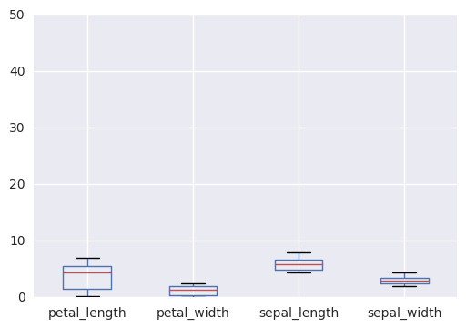

```python
%matplotlib inline
species_group.boxplot(return_type='dict')
```

3.i. Plot a scatter matrix plot using the seaborn library. Use the following to load and plot. a) import seaborn as sns (note: need to install first "conda install seaborn b) Seaborn.pairplot(dataframe, by='column_name')

```python
import seaborn as sns
```

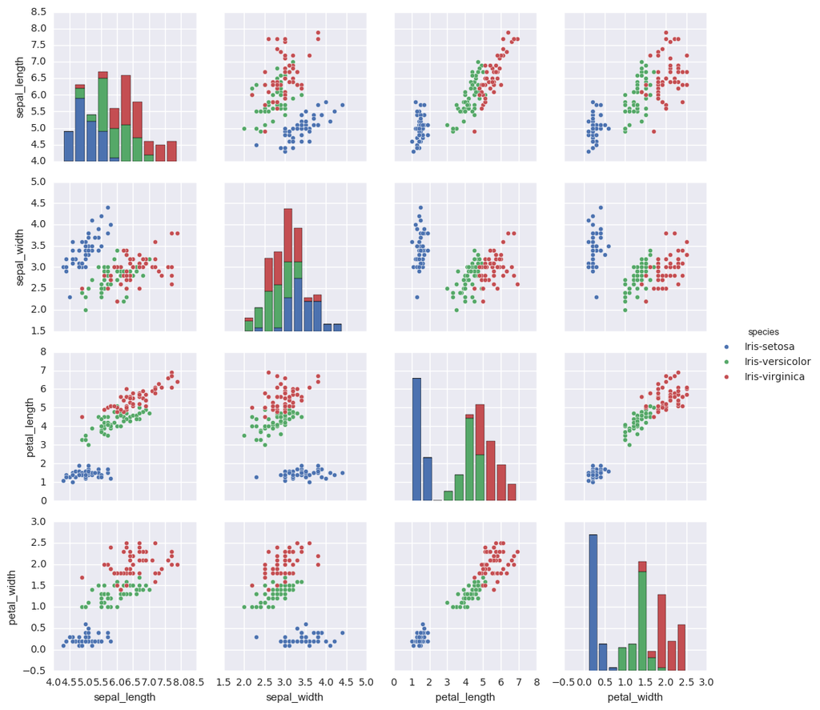

```python
sns.pairplot(iris1, hue='species')
```